# Weather data

## 5.2 Variables for imputation

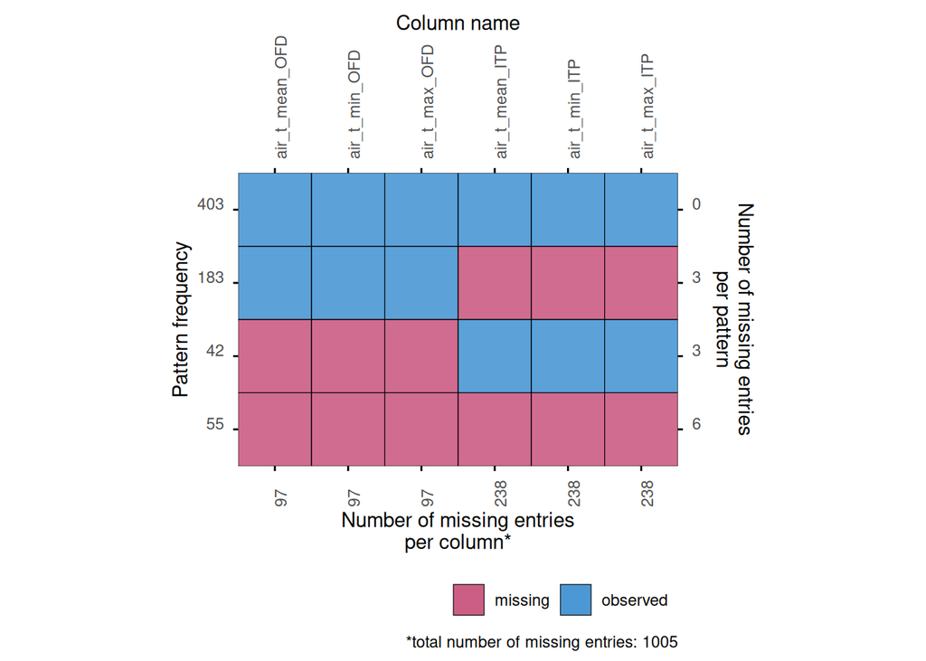

```r
#air T
weat_imp |>
  select(air_t_mean_OFD:air_t_max_ITP) |>
  plot_pattern(rotate = T)
```

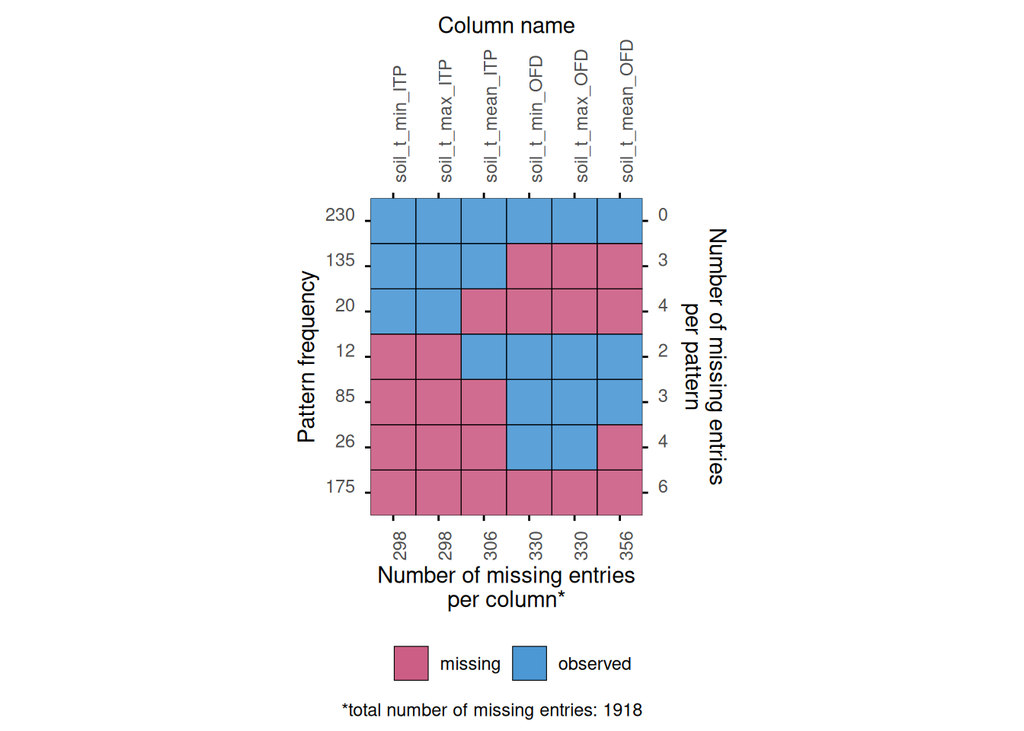

```r
#soil T
weat_imp |>
  select(soil_t_mean_OFD:soil_t_max_ITP) |>
  plot_pattern(rotate = T)
```

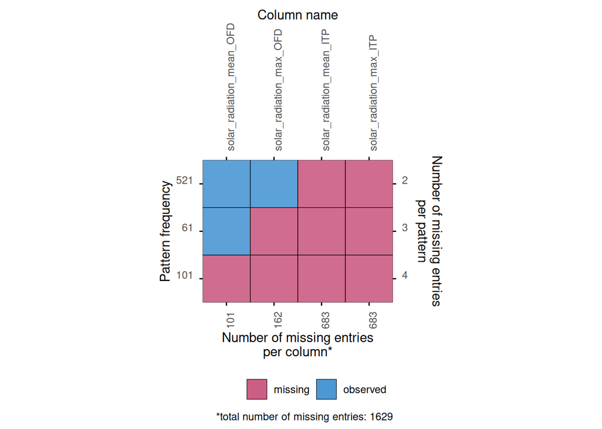

```r
#solar radiation
weat_imp |>
  select(solar_radiation_mean_OFD:solar_radiation_max_ITP) |>
  plot_pattern(rotate = T) # completely missing for ITP
```

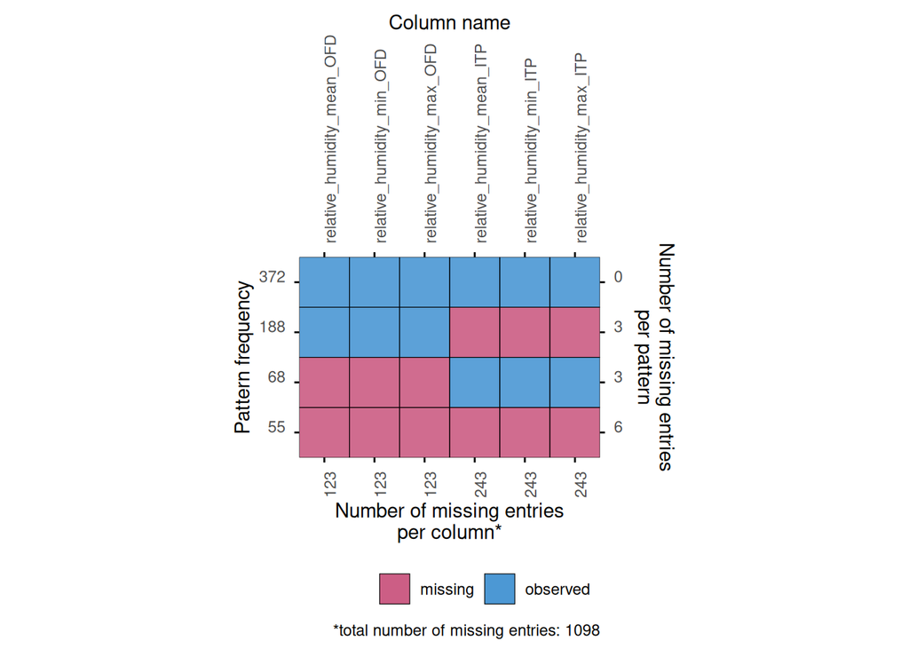

```r
#relative humidity
weat_imp |>
  select(relative_humidity_mean_OFD:relative_humidity_max_ITP) |>
  plot_pattern(rotate = T)
```

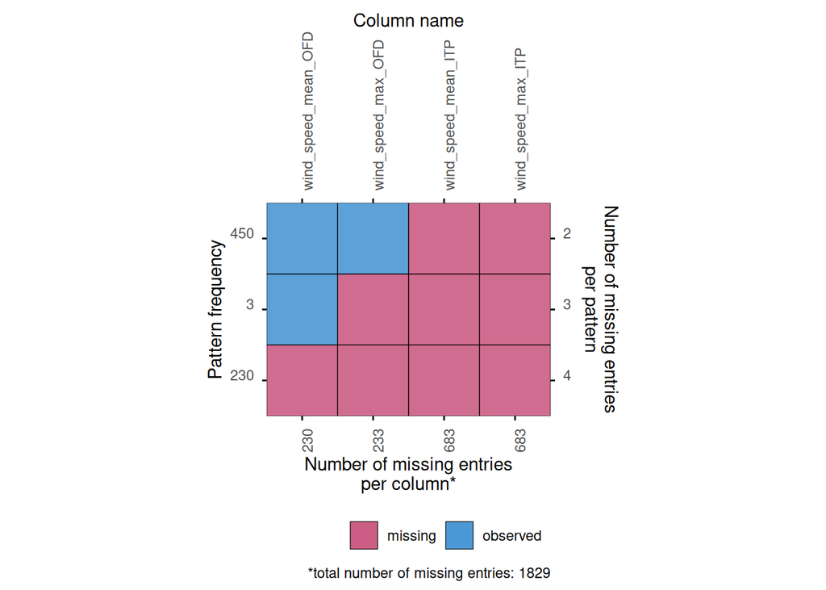

```r
#wind speed
weat_imp |>
  select(wind_speed_mean_OFD:wind_speed_max_ITP) |>
  plot_pattern(rotate = T) # completely missing for ITP
```

```r
#remove min and max columns
weat_imp <- weat_imp |>
  select(!contains(c("min", "max"))) |>
#remove empty columns
  select(!c(solar_radiation_mean_ITP, wind_speed_mean_ITP))
```

Influx and outflux patterns. Variables with high influx are easier to impute, variable with high outflux are more useful to impute other variables. As expected, OFD variables have higher outflux because missingness is generally lower.

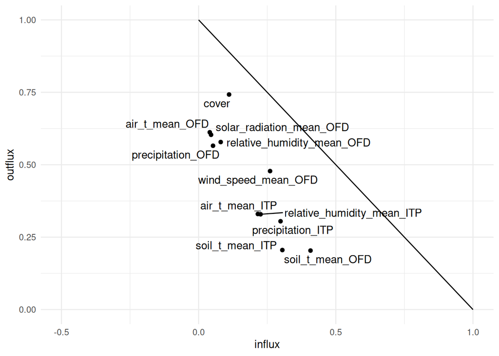

```r
flux(weat_imp[-1:-7]) |>
  select(c(influx, outflux)) |>
  rownames_to_column() |>
  ggplot(aes(x = influx, y = outflux))+
  geom_point()+
  geom_text_repel(aes(label = rowname))+
  annotate("segment", x = 0, y = 1, xend = 1, yend = 0)+
  lims(x = c(-0.5,1), y = 0:1)
```

The following correlation plot reveals an interesting pattern: there are two blocks of related variables, temperature/radiation and humidity/precipitation. Wind speed doesn’t seem to be related to anything, and it’s not used in the analysis models. This informs the selection of which variables to use in the imputation models.

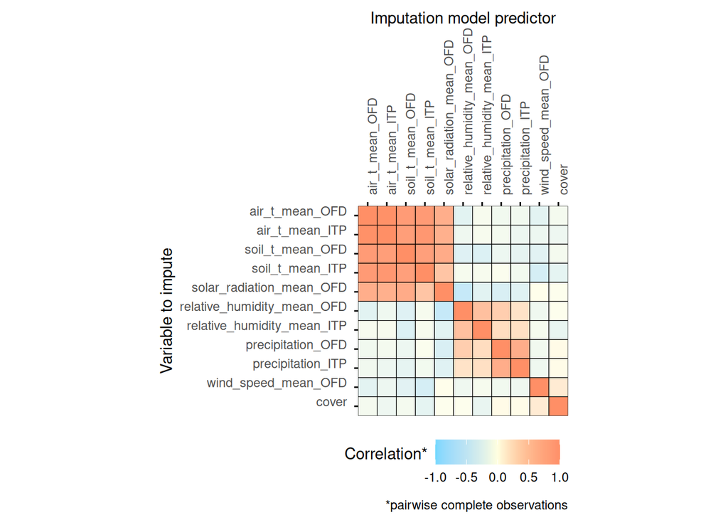

```r
plot_corr(weat_imp[-1:-7], rotate = T, diagonal = T)
```

```r
weat_imp <- weat_imp |>
  select(!wind_speed_mean_OFD)

# identify variable blocks
temp_vars <- colnames(weat_imp)[8:12]

hum_vars <- colnames(weat_imp)[13:16]
```

The ideal case is having OFD data for missing ITP variables of the same block. This happens most of the times. It is also possible to exclude observations with all variables in a block missing.

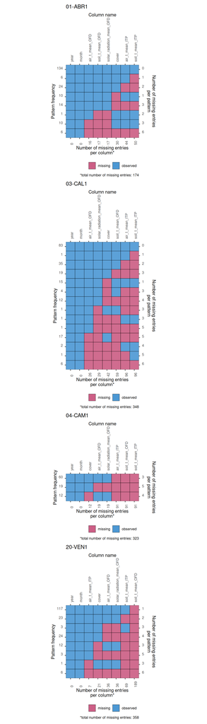

```r
#temperature
weat_imp |>
  nest(.by = site) |>
  deframe() |>
  imap(\(data, site_name) data |>
        select(any_of(c("year", "cover", "month", temp_vars))) |>
        plot_pattern(rotate = T) +
        ggtitle(site_name)) |>
  patchwork::wrap_plots(ncol = 1)
```

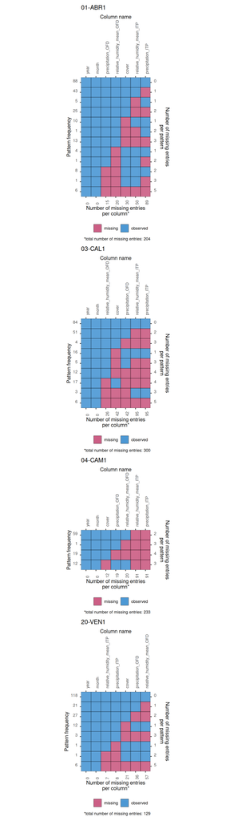

```r
#precipitation
weat_imp |>
  nest(.by = site) |>
  deframe() |>
  imap(\(data, site_name) data |>
        select(any_of(c("year", "cover", "month", hum_vars))) |>
        plot_pattern(rotate = T) +
        ggtitle(site_name)) |>
  patchwork::wrap_plots(ncol = 1)
```

## 5.3 Imputation proper

Next, we set up the imputation. We are using site as predictor: even if some levels are excluded for some outcomes, for lack of sufficient data in that site (especially 04-CAM1), it is better than ignoring it completely.

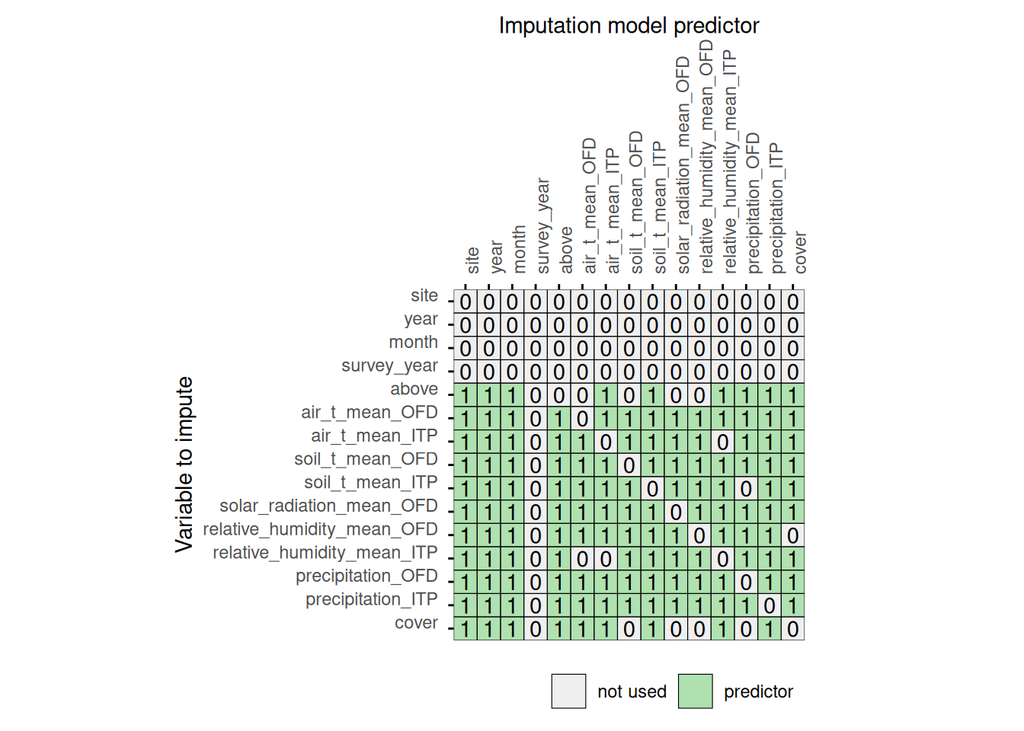

```r
# select outcome depending on analysis model (overall, aboveground, below) and generate separate imputations

imp_above <- weat_imp |>
  select(site:survey_year, above, air_t_mean_OFD:cover)

imp_below <- weat_imp |>
  select(site:survey_year, below, air_t_mean_OFD:cover)

imp_overall <- weat_imp |>
  select(site:survey_year, overall, air_t_mean_OFD:cover)

# don't impute survey_year, this variable is just for later

method_ab <- make.method(imp_above)
method_ab["survey_year"] <- ""

method_bl <- make.method(imp_below)
method_bl["survey_year"] <- ""

method_oa <- make.method(imp_overall)
method_oa["survey_year"] <- ""

#make predictor matrix
predmat_ab <- imp_above |>
  quickpred(include = c("above", "month"), exclude = "survey_year")

#exclude outcomes which are not imputed for clarity
predmat_ab[which(method_ab == ""),] <- 0

#plot
plot_pred(predmat_ab, rotate = T)
```

```r
#copy for other FDs
predmat_bl <- predmat_oa <- predmat_ab

colnames(predmat_bl)[5] <- "below"
rownames(predmat_bl)[5] <- "below"

colnames(predmat_oa)[5] <- "overall"
rownames(predmat_oa)[5] <- "overall"
```

```r
imp_above <- imp_above |>
  mice(predictorMatrix = predmat_ab,
       method = method_ab,
       m = 5, maxit = 100,
       seed = 8274, printFlag = F)

imp_below <- imp_below |>
   mice(predictorMatrix = predmat_bl,
        method = method_bl,
        m = 5, maxit = 100,
        seed = 8274, printFlag = F)

imp_overall <- imp_overall |>
   mice(predictorMatrix = predmat_oa,
        method = method_oa,
        m = 5, maxit = 100,
        seed = 8274, printFlag = F)

#complete and keep only data corresponding to FD surveys
complete_above <- complete(imp_above, action = "long") |>
  semi_join(dates |> mutate(across(everything(), as_factor)))

complete_below <- complete(imp_below, action = "long") |>
  semi_join(dates |> mutate(across(everything(), as_factor)))

complete_overall <- complete(imp_overall, action = "long") |>
  semi_join(dates |> mutate(across(everything(), as_factor)))
```

## 5.4 Imputation diagnostics

Check for NAs, convergence, differences between imputations, imputed against observed data. Since there is heterogeneity in months, the latter is done by month.

```r
#plotting functions
#box plot
bwplot_imp <- function(data, vars) {
  map(vars,
      ~ {
        ggmice(data, aes(x = .imp, y = .data[[.x]])) +
          geom_boxplot() +
          labs(x = "Imputation number")
      }
  ) |>
    patchwork::wrap_plots()&
    theme(legend.position = "none")
}

#density plot
densplot_imp <- function(data, vars) {
  map(vars,
      ~ {
        ggmice(data, aes(x = .data[[.x]], group = .imp, size = .where)) +
          geom_density()+
          scale_size_manual(
            values = c("observed" = 1, "imputed" = 0.5),
            guide = "none")+
          facet_wrap(~month,
                     ncol = 3,
                     strip.position = "right",
                     scales = "free_y",
                     dir = "v")+
          theme(strip.text = element_text(size = 8))+
          ggtitle("month")
      }) |>
    patchwork::wrap_plots(guides = "collect", ncol = 1)&
    theme(legend.position = "bottom")
}

#convergence plot
convplot_imp <- function(data, dia = psrf){
  convergence(data) |>
    filter_out(is.na({{dia}})) |>
    ggplot(aes(x = .it, y = {{dia}})) +
    geom_line() +
    geom_hline(yintercept = 1, linetype = 2, alpha = 0.5) +
    facet_wrap(~vrb)
}

# outcome variables
to_plot <- c("air_t_mean_ITP", "soil_t_mean_ITP", "precipitation_ITP", "relative_humidity_mean_ITP")
```

### 5.4.1 Aboveground

```r
#above
complete_above |>
  summarise(across(everything(), ~ sum(is.na(.x))))
```

| site | year | month | survey_year | above | air_t_mean_OFD | air_t_mean_ITP | soil_t_mean_OFD | soil_t_mean_ITP | solar_radiation_mean_OFD | relative_humidity_mean_OFD | relative_humidity_mean_ITP | precipitation_OFD | precipitation_ITP | cover | .imp | .id |
| --- | --- | --- | --- | --- | --- | --- | --- | --- | --- | --- | --- | --- | --- | --- | --- | --- |
| 0 | 0 | 0 | 0 | 0 | 0 | 0 | 0 | 0 | 0 | 0 | 0 | 0 | 0 | 0 | 0 | 0 |

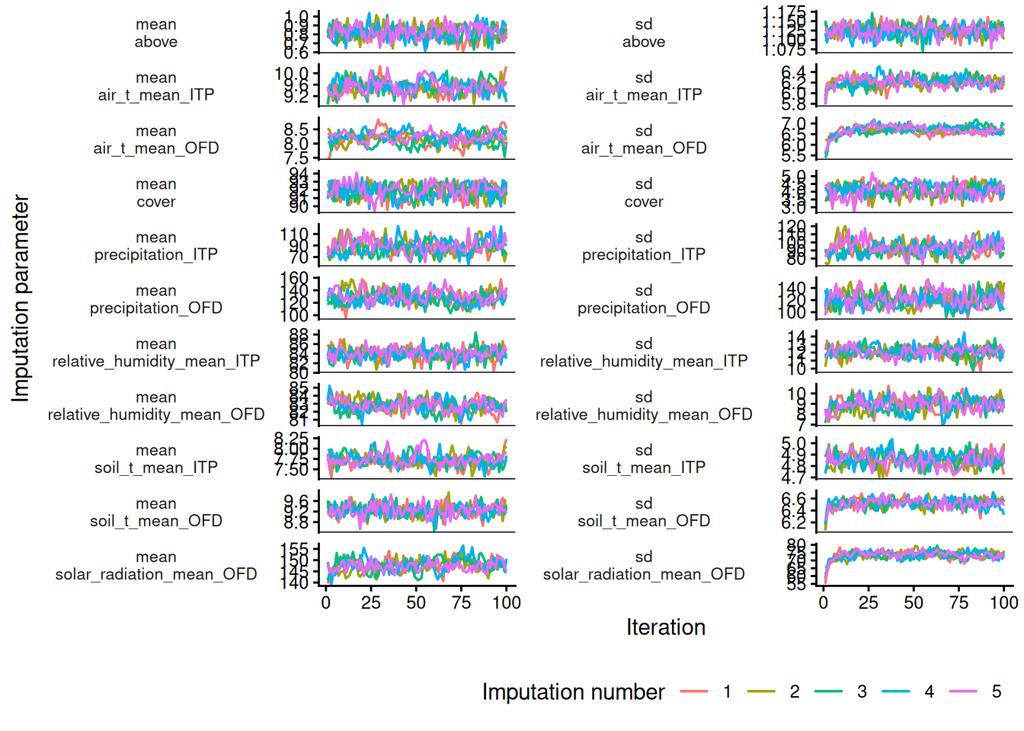

```r
plot_trace(imp_above) +
  theme(strip.text.y.left = element_text(size = 8, angle = 0))
```

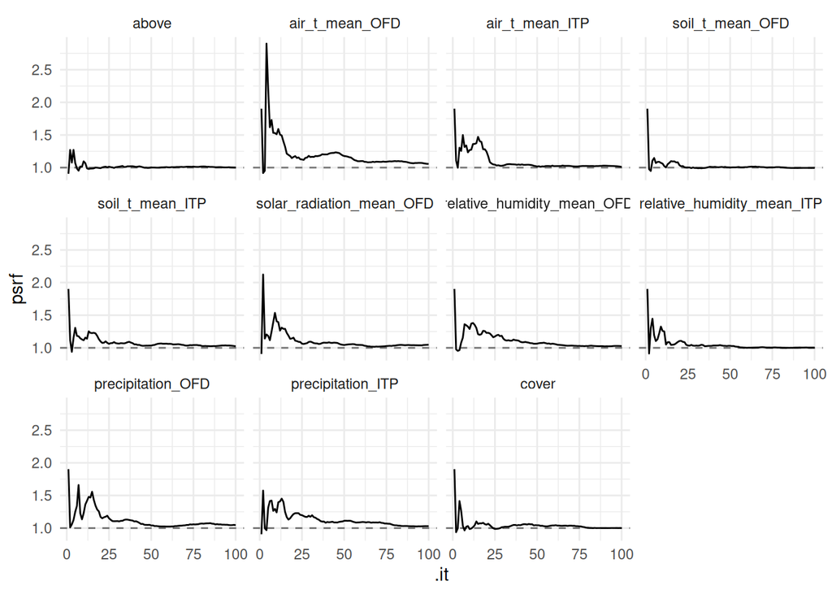

```r
convplot_imp(imp_above)
```

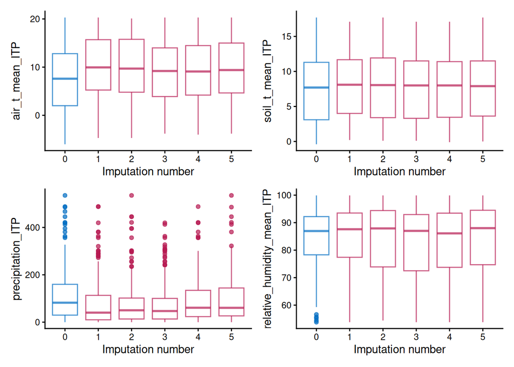

```r
bwplot_imp(imp_above, to_plot)
```

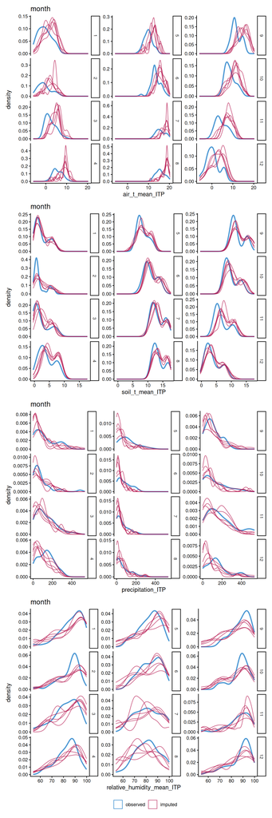

```r
densplot_imp(imp_above, to_plot)
```

### 5.4.2 Belowground

```r
#below
complete_below |>
  select(!survey_year) |>
  summarise(across(everything(), ~ sum(is.na(.x))))
```

| site | year | month | below | air_t_mean_OFD | air_t_mean_ITP | soil_t_mean_OFD | soil_t_mean_ITP | solar_radiation_mean_OFD | relative_humidity_mean_OFD | relative_humidity_mean_ITP | precipitation_OFD | precipitation_ITP | cover | .imp | .id |
| --- | --- | --- | --- | --- | --- | --- | --- | --- | --- | --- | --- | --- | --- | --- | --- |
| 0 | 0 | 0 | 0 | 0 | 0 | 0 | 0 | 0 | 0 | 0 | 0 | 0 | 0 | 0 | 0 |

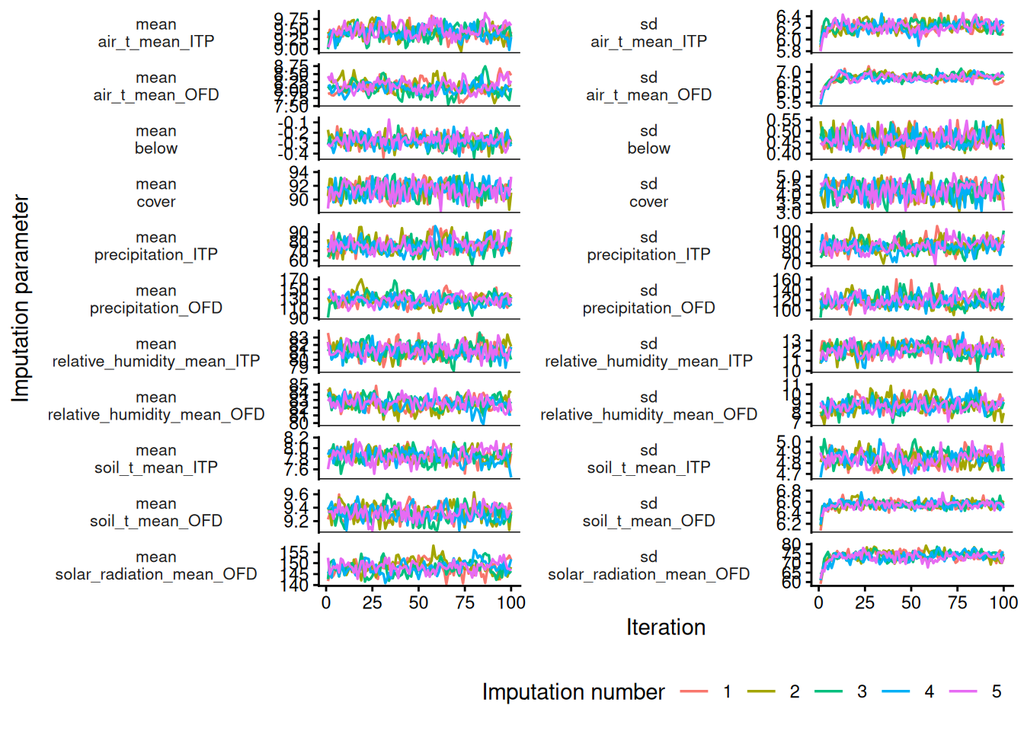

```r
plot_trace(imp_below) +
  theme(strip.text.y.left = element_text(size = 8, angle = 0))
```

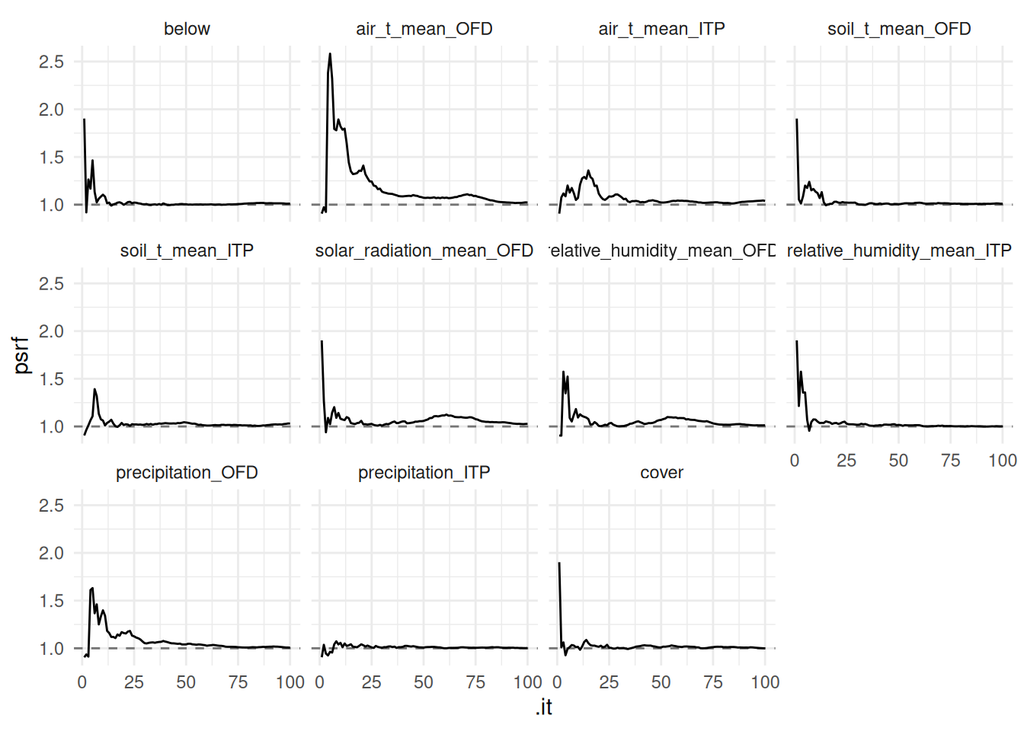

```r
convplot_imp(imp_below)
```

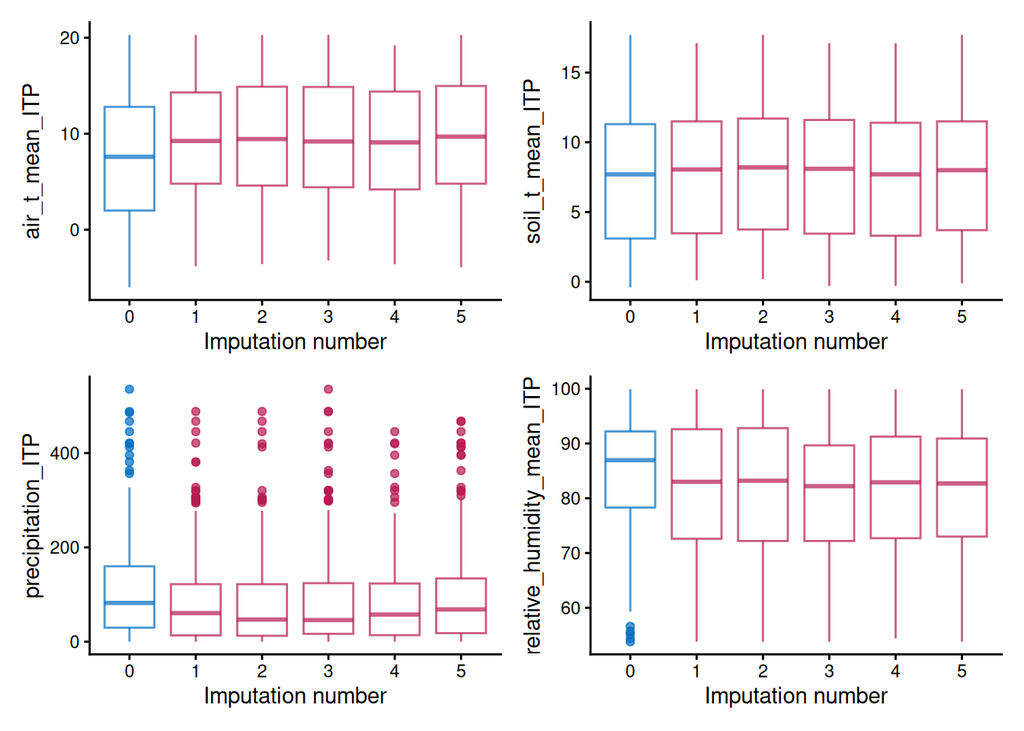

```r
bwplot_imp(imp_below, to_plot)
```

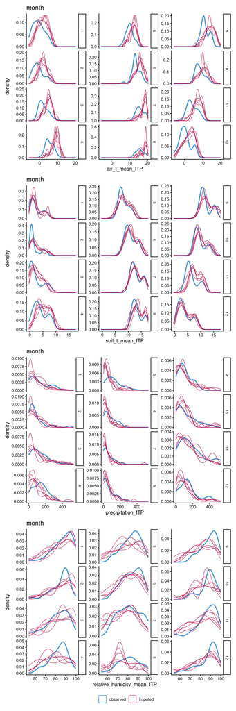

```r
densplot_imp(imp_below, to_plot)
```

### 5.4.3 Overall

```r
#overall
complete_overall |>
  select(!survey_year) |>
  summarise(across(everything(), ~ sum(is.na(.x))))
```

| site | year | month | overall | air_t_mean_OFD | air_t_mean_ITP | soil_t_mean_OFD | soil_t_mean_ITP | solar_radiation_mean_OFD | relative_humidity_mean_OFD | relative_humidity_mean_ITP | precipitation_OFD | precipitation_ITP | cover | .imp | .id |
| --- | --- | --- | --- | --- | --- | --- | --- | --- | --- | --- | --- | --- | --- | --- | --- |
| 0 | 0 | 0 | 0 | 0 | 0 | 0 | 0 | 0 | 0 | 0 | 0 | 0 | 0 | 0 | 0 |

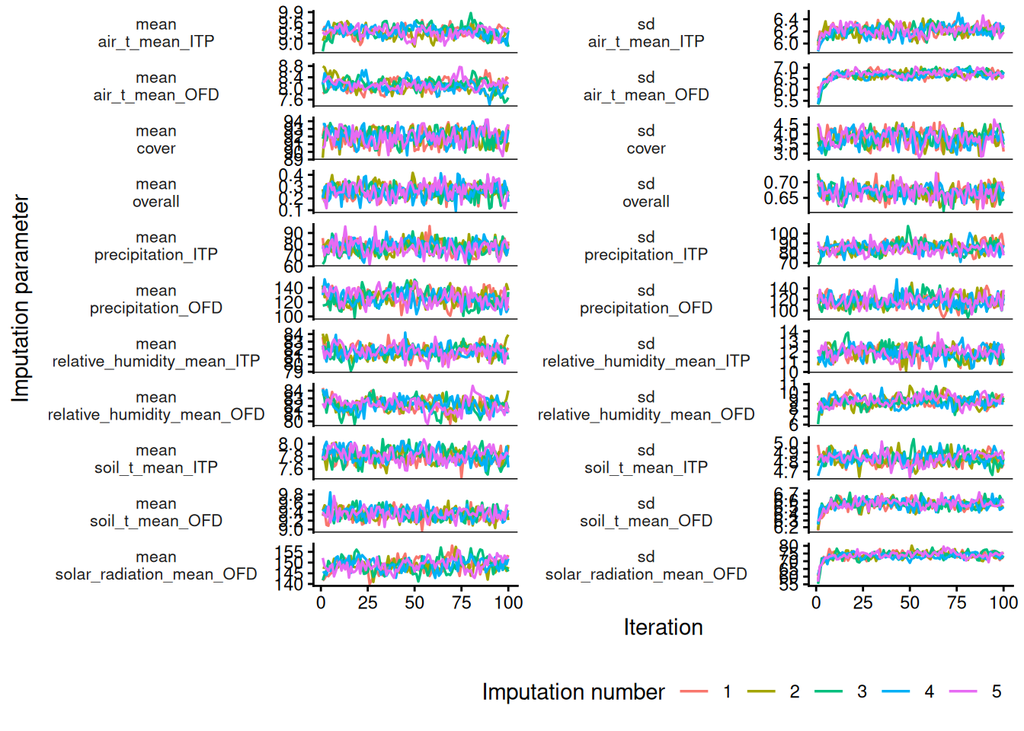

```r
plot_trace(imp_overall) +
  theme(strip.text.y.left = element_text(size = 8, angle = 0))
```

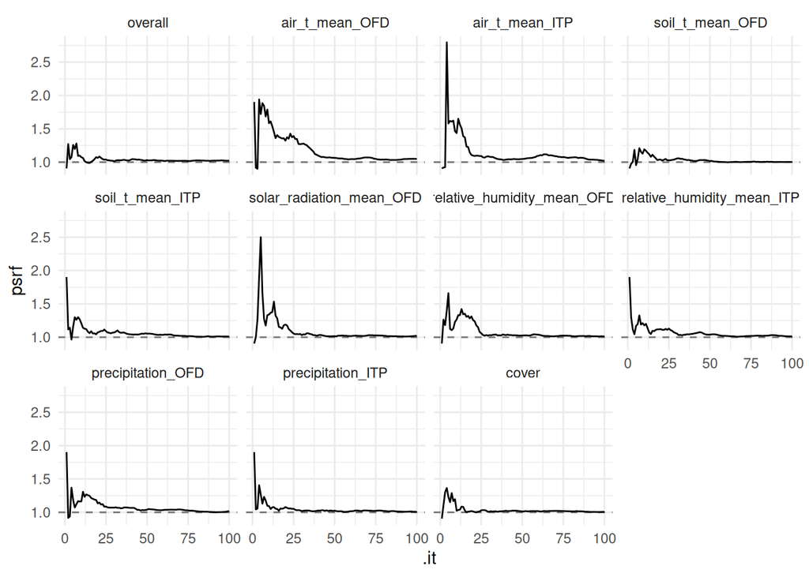

```r
convplot_imp(imp_overall)
```

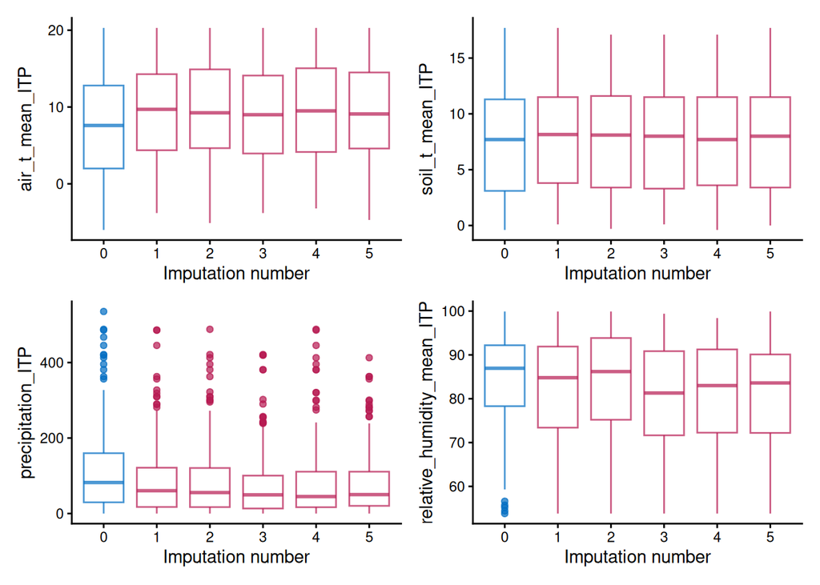

```r
bwplot_imp(imp_overall, to_plot)
```

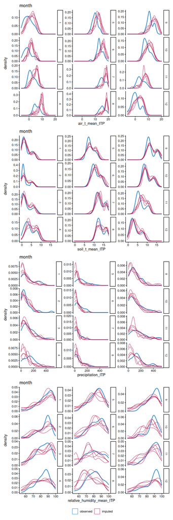

```r
densplot_imp(imp_overall, to_plot)
```

# 6 Plot weather data

## 6.1 Open-field data

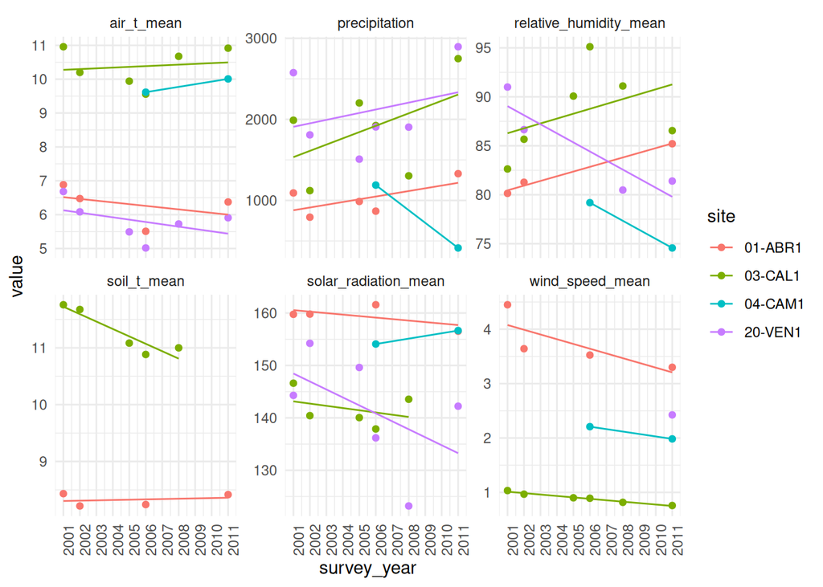

```r
complete_OFD |>
  imap(\(x, idx) x |>
         rename(value = matches(idx))) |>
  bind_rows(.id = "variable") |>
  ggplot(aes(x = survey_year, y = value, color = site))+
  geom_point()+
  geom_smooth(method = "lm", se = F, linewidth = 0.5)+
  scale_x_continuous(limits = c(2001, 2011),
                     breaks = scales::breaks_width(1))+
  facet_wrap(~variable, ncol = 3, scales = "free_y")+
  theme(axis.text.x = element_text(angle = 90))
```

## 6.2 Sub-canopy data

Here are the annual means for each of the multiple imputations. It is clear that there is much more uncertainty for 04-CAM1, the site with more missing data. Using the multiply imputed datasets will reflect this uncertainty in the analysis.

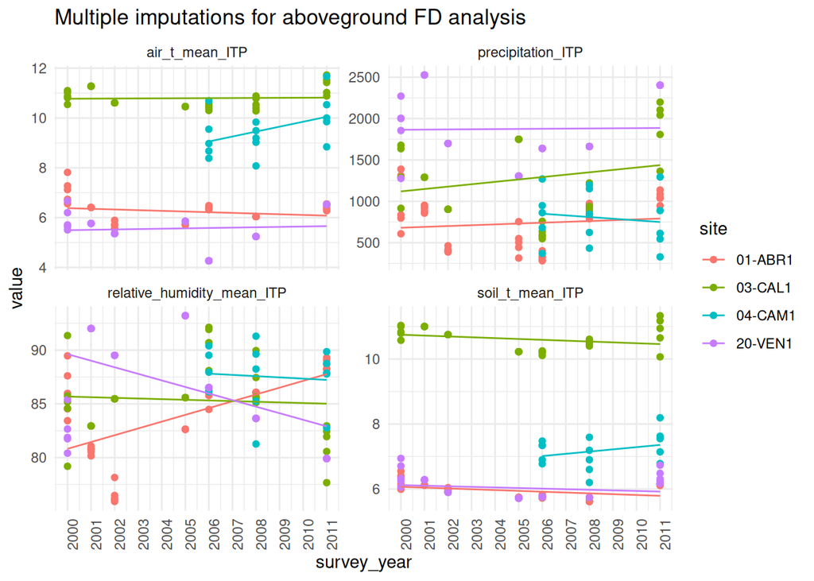

```r
plot_complete <- function(x){
  x |>
    select(c(site, survey_year, .imp, .id, contains("ITP"))) |>
    mutate(survey_year = as.numeric(levels(survey_year)[survey_year])) |>
    group_by(site, survey_year, .imp) |>
    summarise(across(everything(), mean), .groups = "drop") |>
    mutate(precipitation_ITP = precipitation_ITP * 12) |>
    pivot_longer(contains("ITP"), names_to = "variable", values_to = "value") |>
    ggplot(aes(x = survey_year, y = value, color = site))+
    geom_point()+
    geom_smooth(method = "lm", se = F, linewidth = 0.5)+
    scale_x_continuous(limits = c(2000, 2011),
                     breaks = scales::breaks_width(1))+
    facet_wrap(~variable, scales = "free_y")+
    theme(axis.text.x = element_text(angle = 90))
}

complete_above |>
  plot_complete() +
  ggtitle("Multiple imputations for aboveground FD analysis")
```

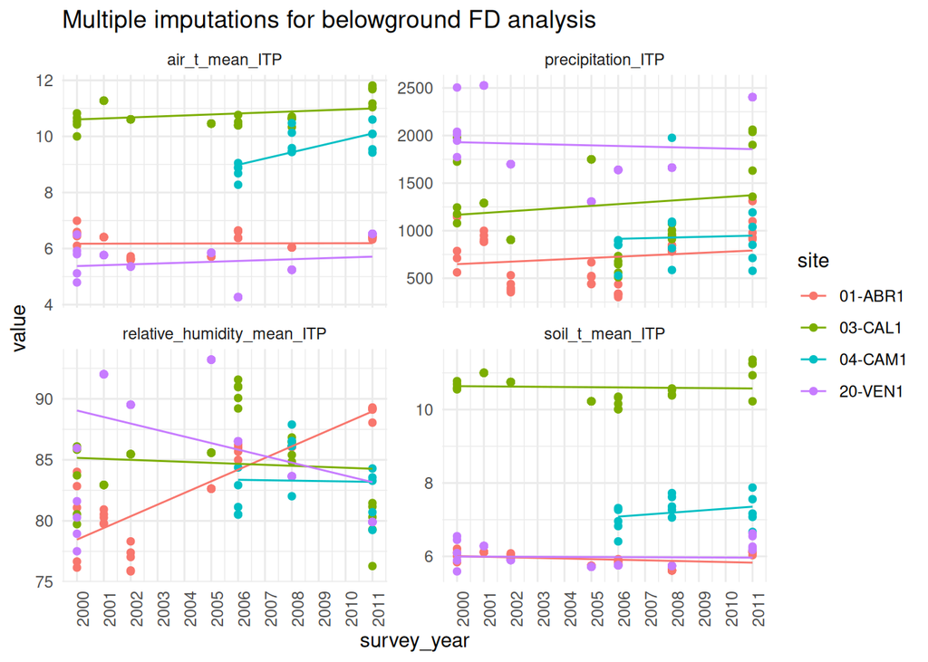

```r
complete_below |>
  plot_complete() +
  ggtitle("Multiple imputations for belowground FD analysis")
```

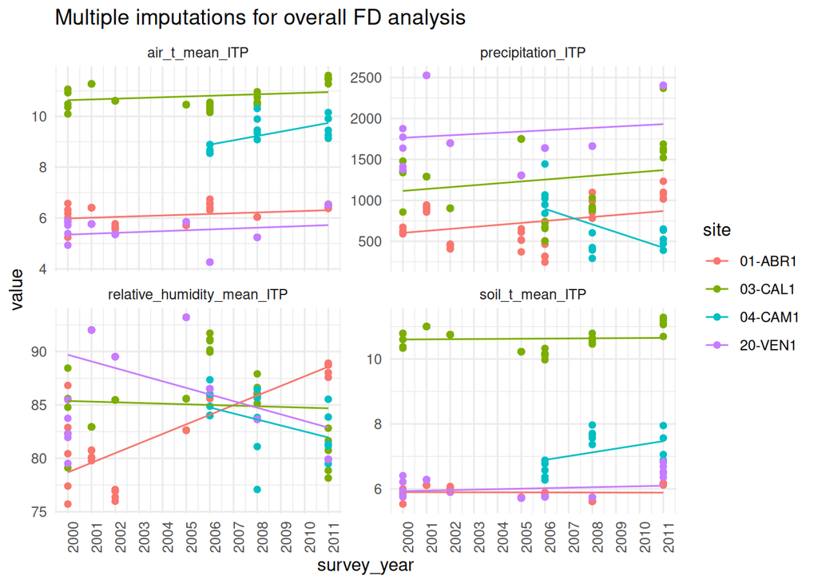

```r
complete_overall |>
  plot_complete() +
  ggtitle("Multiple imputations for overall FD analysis")
```